# Конкурс красоты кода от Сбера 2024

## Содержание

- 1. Предобработка и первичный анализ данных 💎
- 2. Feature engineering 🛠
- 3. Обучение модели ⚙️
- 4. Оценка модели 📊
- 5. Интеграция модели 🔥

Импортируем необходимые **библиотеки**:

```python
import numpy as np
import pandas as pd

from sklearn.model_selection import train_test_split
from sklearn.metrics import accuracy_score, f1_score, precision_score, recall_score, roc_auc_score, roc_curve, auc
from sklearn.preprocessing import KBinsDiscretizer
from sklearn.metrics import ConfusionMatrixDisplay, confusion_matrix

from scipy import stats

from sklearn.linear_model import LogisticRegression
from sklearn.ensemble import RandomForestClassifier
from lightgbm import LGBMClassifier
import lightgbm

from category_encoders import BaseNEncoder
from sklearn.preprocessing import MinMaxScaler

import optuna
optuna.logging.set_verbosity(optuna.logging.WARNING)
from optuna.samplers import TPESampler

import matplotlib.pyplot as plt
import seaborn as sns

import warnings
warnings.filterwarnings("ignore")
```

Сделаем будущие результаты вновь воспроизводимыми:

```python
RANDOM_STATE = 1

np.random.seed(RANDOM_STATE)
```

# 1. Предобработка и первичный анализ данных 💎

**В данном разделе будут сделаны следующие пункты:**

- проведём анализ данных для выявления корреляций между признаками
- очистим данные от пропусков и аномальных значений
- преобразуем категориальные переменные в числовые
- построим графики, иллюстрирующие распределение данных, корреляции между признаками
- разделим данные на тренировочную, валидационную и тестовую выборки

**В процессе данного раздела мы узнаем** больше сведений о данных, которые помогут нам при принятии решения о классе будущих моделей (линейные или нелинейные), увидим распределения данных, узнаем про дизбаланс классов в таргете и связь признаков с целевой переменной.

**Из-за того, что в датасете, прикреплённом к заданию, было всего 3 примера данных, я нашёл датасет в открытых источниках, который подходит под требования к исходным данным из описания трека "AI"**: https://www.kaggle.com/datasets/mathchi/churn-for-bank-customers

**Описание датасета** (ровно такие же признаки упомянуты в описании кейса на сайте в треке "AI": https://beautifulcode.ru/task/ai):

- `CustomerID`: уникальный идентификатор клиента
- `Age`: возраст клиента
- `Gender`: пол клиента
- `Tenure`: срок обслуживания клиента в банке (в годах)
- `Balance`: баланс на счету клиента
- `NumOfProducts`: количество продуктов банка, используемых клиентом
- `HasCrCard`: наличие кредитной карты (1 – да, 0 – нет)
- `IsActiveMember`: является ли клиент активным пользователем услуг банка (1 – да, 0 – нет)
- `EstimatedSalary`: оценка заработной платы клиента
- `Exited`: целевой столбец, который указывает на то, покинул ли клиент банк (1 – да, 0 – нет)

```python
df = pd.read_csv('data/dataset.csv')
df
```

|  | CustomerId | Age | Gender | Tenure | Balance | NumOfProducts | HasCrCard | IsActiveMember | EstimatedSalary | Exited |
| --- | --- | --- | --- | --- | --- | --- | --- | --- | --- | --- |
| 0 | 15634602 | 42 | Female | 2 | 0.00 | 1 | 1 | 1 | 101348.88 | 1 |
| 1 | 15647311 | 41 | Female | 1 | 83807.86 | 1 | 0 | 1 | 112542.58 | 0 |
| 2 | 15619304 | 42 | Female | 8 | 159660.80 | 3 | 1 | 0 | 113931.57 | 1 |
| 3 | 15701354 | 39 | Female | 1 | 0.00 | 2 | 0 | 0 | 93826.63 | 0 |
| 4 | 15737888 | 43 | Female | 2 | 125510.82 | 1 | 1 | 1 | 79084.10 | 0 |
| ... | ... | ... | ... | ... | ... | ... | ... | ... | ... | ... |
| 9995 | 15606229 | 39 | Male | 5 | 0.00 | 2 | 1 | 0 | 96270.64 | 0 |
| 9996 | 15569892 | 35 | Male | 10 | 57369.61 | 1 | 1 | 1 | 101699.77 | 0 |
| 9997 | 15584532 | 36 | Female | 7 | 0.00 | 1 | 0 | 1 | 42085.58 | 1 |
| 9998 | 15682355 | 42 | Male | 3 | 75075.31 | 2 | 1 | 0 | 92888.52 | 1 |
| 9999 | 15628319 | 28 | Female | 4 | 130142.79 | 1 | 1 | 0 | 38190.78 | 0 |

10000 rows × 10 columns

Посмотрим на **тип данных каждого столбца**:

```python
df.info()
```

```
<class 'pandas.core.frame.DataFrame'>
RangeIndex: 10000 entries, 0 to 9999
Data columns (total 10 columns):
 #   Column           Non-Null Count  Dtype
---  ------           --------------  -----
 0   CustomerId       10000 non-null  int64
 1   Age              10000 non-null  int64
 2   Gender           10000 non-null  object
 3   Tenure           10000 non-null  int64
 4   Balance          10000 non-null  float64
 5   NumOfProducts    10000 non-null  int64
 6   HasCrCard        10000 non-null  int64
 7   IsActiveMember   10000 non-null  int64
 8   EstimatedSalary  10000 non-null  float64
 9   Exited           10000 non-null  int64
dtypes: float64(2), int64(7), object(1)
memory usage: 781.4+ KB
```

Посмотрим на **кол-во уникальных значений в каждом столбце**:

```python
df.nunique()
```

```
CustomerId         10000
Age                   70
Gender                 2
Tenure                11
Balance             6382
NumOfProducts          4
HasCrCard              2
IsActiveMember         2
EstimatedSalary     9999
Exited                 2
dtype: int64
```

Заметим следующее:

- `CustomerId` столько же, сколько и данных. Именно поэтому данный признак не информативен, так как каждый айдишник уникален и его следует удалить.
- `HasCrCard` и `IsActiveMember` являются категориалыми признаками, обозначающие да/нет. Их тип данных следует перевести в категориальный.
- `Tenure` и `NumOfProducts` принимают малое кол-во значение, но в теории их может быть и больше, так как кол-во продуктов компании может в будущем вырасти, как и срок обслуживания клиента в банке в годах. Вероятно эти признаки стоит рассмотреть как численные, так и категориальные. Но на данном этапе я принял решение рассматривать их как категориальные признаки.

```python
df = df.drop(columns=['CustomerId'])

df = df.astype({
    'HasCrCard': 'category',
    'IsActiveMember': 'category',
    'Gender': 'category',
    'NumOfProducts': 'category',
    'Tenure': 'category',
    'Exited': 'category',
})

df.info()
```

```
<class 'pandas.core.frame.DataFrame'>
RangeIndex: 10000 entries, 0 to 9999
Data columns (total 9 columns):
 #   Column           Non-Null Count  Dtype
---  ------           --------------  -----
 0   Age              10000 non-null  int64
 1   Gender           10000 non-null  category
 2   Tenure           10000 non-null  category
 3   Balance          10000 non-null  float64
 4   NumOfProducts    10000 non-null  category
 5   HasCrCard        10000 non-null  category
 6   IsActiveMember   10000 non-null  category
 7   EstimatedSalary  10000 non-null  float64
 8   Exited           10000 non-null  category
dtypes: category(6), float64(2), int64(1)
memory usage: 294.2 KB
```

```python
def describe_nums(df: pd.DataFrame) -> pd.DataFrame:
    """Вывод статистик численных признаков.
    return: pd.DataFrame - посчитанные статистики. """
    df = df.select_dtypes(include=['int64', 'float64'])
    return pd.concat([df.describe().T,
                      df.skew().rename('skew'),
                      df.kurt().rename('kurt'),
                     ], axis=1).T
```

```python
describe_nums(df)
```

|  | Age | Balance | EstimatedSalary |
| --- | --- | --- | --- |
| count | 10000.000000 | 10000.000000 | 10000.000000 |
| mean | 38.921800 | 76485.889288 | 100090.239881 |
| std | 10.487806 | 62397.405202 | 57510.492818 |
| min | 18.000000 | 0.000000 | 11.580000 |
| 25% | 32.000000 | 0.000000 | 51002.110000 |
| 50% | 37.000000 | 97198.540000 | 100193.915000 |
| 75% | 44.000000 | 127644.240000 | 149388.247500 |
| max | 92.000000 | 250898.090000 | 199992.480000 |
| skew | 1.011320 | -0.141109 | 0.002085 |
| kurt | 1.395347 | -1.489412 | -1.181518 |

**Информация о категориальных признаках**:

```python
df.describe(include=['category'])
```

|  | Gender | Tenure | NumOfProducts | HasCrCard | IsActiveMember | Exited |
| --- | --- | --- | --- | --- | --- | --- |
| count | 10000 | 10000 | 10000 | 10000 | 10000 | 10000 |
| unique | 2 | 11 | 4 | 2 | 2 | 2 |
| top | Male | 2 | 1 | 1 | 1 | 0 |
| freq | 5457 | 1048 | 5084 | 7055 | 5151 | 7963 |

Посмотрим на **пропуски в данных**. Их нет.

```python
df.isna().sum()
```

```
Age                0
Gender             0
Tenure             0
Balance            0
NumOfProducts      0
HasCrCard          0
IsActiveMember     0
EstimatedSalary    0
Exited             0
dtype: int64
```

Посмотрим на **распределение таргета в данных**. Видим, что у нас дизбаланс целевой переменной в данных. В будущем с этим придётся что-то делать.

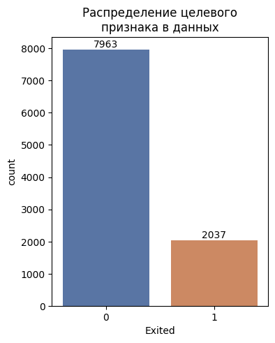

```python
tmp = df.Exited.value_counts().reset_index()

plt.figure(figsize=(4, 5))
plt.title('Распределение целевого\nпризнака в данных')
ax = sns.barplot(tmp, x="Exited", y="count", errorbar=None, palette="deep")
ax.bar_label(ax.containers[0], fontsize=10);
```

Посмотрим на **распределение таргета в зависимости от категориальных признаков**.

По графикам можно заметить, что:

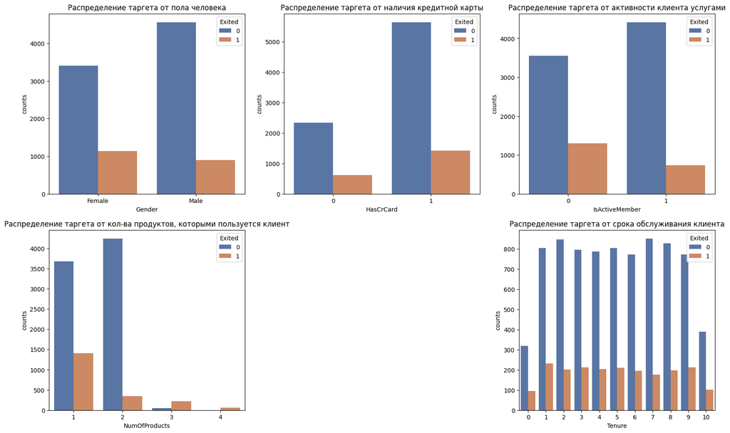

```python
plt.figure(figsize=(20, 12))

tmp = df.groupby(['Exited', 'Gender']).size().reset_index(name='counts')
plt.subplot(2, 3, 1)
plt.title('Распределение таргета от пола человека')
sns.barplot(tmp, x="Gender", y='counts', hue='Exited', errorbar=None, palette="deep")

tmp = df.groupby(['Exited', 'HasCrCard']).size().reset_index(name='counts')
plt.subplot(2, 3, 2)
plt.title('Распределение таргета от наличия кредитной карты')
sns.barplot(tmp, x="HasCrCard", y="counts", hue='Exited', errorbar=None, palette="deep")

tmp = df.groupby(['Exited', 'IsActiveMember']).size().reset_index(name='counts')
plt.subplot(2, 3, 3)
plt.title('Распределение таргета от активности клиента услугами')
sns.barplot(tmp, x="IsActiveMember", y="counts", hue='Exited', errorbar=None, palette="deep")

tmp = df.groupby(['Exited', 'NumOfProducts']).size().reset_index(name='counts')
plt.subplot(2, 3, 4)
plt.title('Распределение таргета от кол-ва продуктов, которыми пользуется клиент')
sns.barplot(tmp, x="NumOfProducts", y="counts", hue='Exited', errorbar=None, palette="deep")

tmp = df.groupby(['Exited', 'Tenure']).size().reset_index(name='counts')
plt.subplot(2, 3, 6)
plt.title('Распределение таргета от срока обслуживания клиента')
sns.barplot(tmp, x="Tenure", y="counts", hue='Exited', errorbar=None, palette="deep");
```

Посмотрим на **распределение численных признаков от таргета**. Судя по графикам, `связь не линейная между численным признаком и таргетом`.

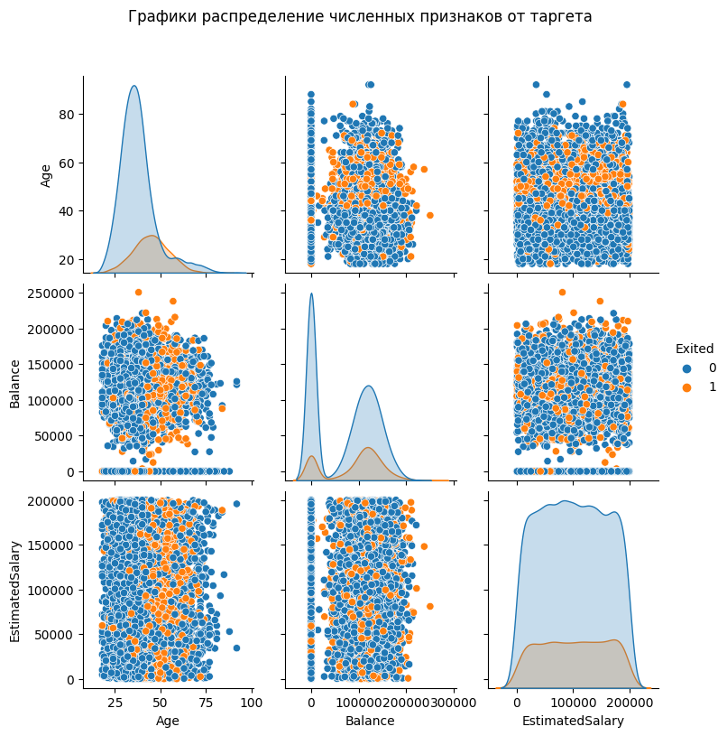

```python
df_tmp = df.select_dtypes(include=['int64', 'float64'])
df_tmp['Exited'] = df['Exited']
g = sns.pairplot(df_tmp, hue='Exited')
g.fig.suptitle("Графики распределение численных признаков от таргета", y=1.08);
```

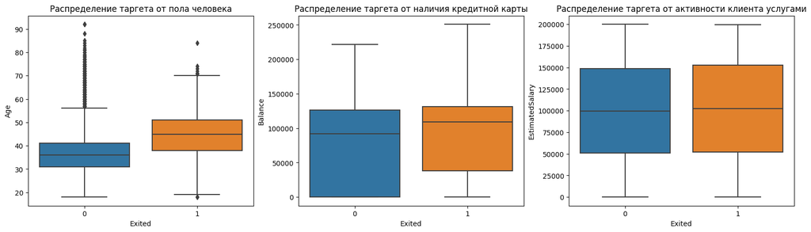

```python
plt.figure(figsize=(20, 5))

plt.subplot(1, 3, 1)
plt.title('Распределение таргета от пола человека')
sns.boxplot(x='Exited', y='Age', data=df)

plt.subplot(1, 3, 2)
plt.title('Распределение таргета от наличия кредитной карты')
sns.boxplot(x='Exited', y='Balance', data=df)

plt.subplot(1, 3, 3)
plt.title('Распределение таргета от активности клиента услугами')
sns.boxplot(x='Exited', y='EstimatedSalary', data=df);
```

**Преобразуем пол человека в численный вид**, чтобы дальнейшие преобразования данных работали корректно (0-женщина, 1-мужчина).

```python
df.Gender = df.Gender.values.codes
df.Gender = df.Gender.astype('category')
df.head(2)
```

|  | Age | Gender | Tenure | Balance | NumOfProducts | HasCrCard | IsActiveMember | EstimatedSalary | Exited |
| --- | --- | --- | --- | --- | --- | --- | --- | --- | --- |
| 0 | 42 | 0 | 2 | 0.00 | 1 | 1 | 1 | 101348.88 | 1 |
| 1 | 41 | 0 | 1 | 83807.86 | 1 | 0 | 1 | 112542.58 | 0 |

Для дальнейшей работы отделим целевую переменную от признаков:

```python
target_column = 'Exited'

X = df.drop(columns=[target_column])
y = df[target_column]
```

Сделаем **матрицу корреляции между признаками**. Высокая корреляция между признаками может привести к:

- `потере информативности`, т.е. когда признаки сильно коррелированы, один из них может не добавлять новой информации в модель. Это приводит к избыточности, что может усложнить интерпретацию результатов.
- `проблеме с оценкой коэффициентов в линейных моделях`. Мультиколлинеарность делает трудным определение влияния каждого признака на целевую переменную.

Мы видим, что имеется связь между двумя признаками: `NumOfProducts` и `Balance`. Но коэф. корреляции у них не слишком большой и поэтому пока устранять их не стоит. В остальным случаях она почти нулевая.

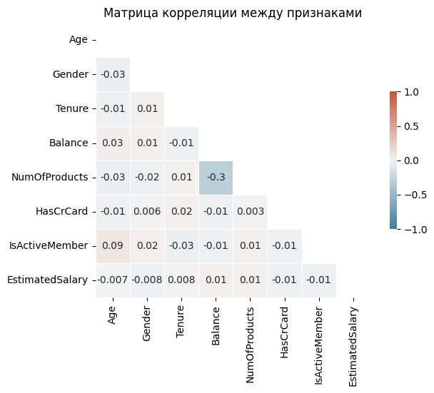

```python
corr = X.corr()

mask = np.triu(np.ones_like(corr, dtype=bool))

f, ax = plt.subplots(figsize=(7, 5))
cmap = sns.diverging_palette(230, 20, as_cmap=True)
ax.set_title('Матрица корреляции между признаками')
sns.heatmap(corr, mask=mask, cmap=cmap, vmin=-1, vmax=1, center=0,
            square=True, linewidths=.5, cbar_kws={"shrink": .5}, annot=True, fmt='.1g');
```

Создадим график корреляции признаков с таргетом. По нему видно, что таргет сильнее всего коррелирует с `Age`, `IsActiveMember` и чуть слабее с `Gender` и `Balance`.

Таким образом, мы видим, что линейная связь признаков с таргетом имеется, но она **не слишком сильная и далеко не все признаки имеют эту связь**. В будущем вероятно нужно будет сделать преобразования для усиления линейной связи с таргетом, либо подумать над нелинейными моделями.

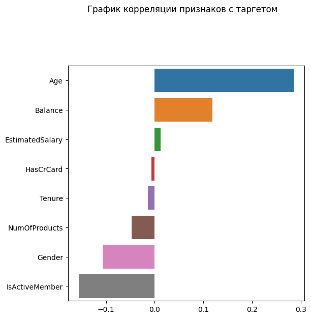

```python
correlations = X.corrwith(y).sort_values(ascending=False)

plot = sns.barplot(y=correlations.index, x=correlations)
plot.figure.suptitle("График корреляции признаков с таргетом", y=1.08);
plot.figure.set_size_inches(6, 6)
```

Для последующей работы с данными, их преобразованиями и тестирования различных моделей нам следует поделить данные на **тренировочную** и **валидационную выборки**.

```python
X_train, X_valid, y_train, y_valid = train_test_split(X, y, test_size=0.3, random_state=RANDOM_STATE)

print(X_train.shape, X_valid.shape)
```

```
(7000, 8) (3000, 8)
```

Также нам создать **тестовую выборку**. Это нужно для того, чтобы на тренировочной выборке обучать веса модели, на валидационной модели подбирать в будущем лучшие гиперпараметры модели, а на тестовой уже считать итоговую метрику качества работы модели.

Делить на валидационную и тестовую выборки важно, так как есть `большая вероятность, что гиперпараметры модели можут переобучиться под валидационную выборку и показывать хорошие результаты`. Но так как мы хотим создать модель, способную обобщать различные данные, нам нужна ещё одна выборка - тестовая, на которой и будет оцениваться работа всего pipeline.

```python
X_valid, X_test, y_valid, y_test = train_test_split(X_valid, y_valid, test_size=0.5, random_state=RANDOM_STATE)

print(X_valid.shape, X_test.shape)
```

```
(1500, 8) (1500, 8)
```

Посмотрим какое распределение таргета в `train`,`valid` и `test` выборках.

```python
y_train.value_counts()
```

```
Exited
0    5590
1    1410
Name: count, dtype: int64
```

```python
y_valid.value_counts()
```

```
Exited
0    1181
1     319
Name: count, dtype: int64
```

```python
y_test.value_counts()
```

```
Exited
0    1192
1     308
Name: count, dtype: int64
```

Из-за того, что **распределение классов в данных несбалансированно**, требуется это как-то исправить. **Сделаем коррекцию весов для каждого класса**, чтобы модель корректировала своё обучение под дизбаланс классов. Если этого не сделать, то модель может всегда предсказывать тот класс, которого очень много в данных и ей это будет выгодно, а нам наоборот нужна адекватная модель.

```python
from sklearn.utils.class_weight import compute_class_weight

classes = np.unique(y_train)
weights = compute_class_weight(class_weight='balanced', classes=classes, y=y_train)
class_weights = dict(zip(classes, weights))

print(f'Класс 0 имеет вес = {round(class_weights[0], 2)}')
print(f'Класс 1 имеет вес = {round(class_weights[1], 2)}')
```

```
Класс 0 имеет вес = 0.63
Класс 1 имеет вес = 2.48
```

# 2. Feature engineering 🛠

**В данном разделе будут сделаны следующие пункты**:

- создание новых признаков на основе имеющихся данных
- масштабирование признаков для улучшения качества модели

Прежде чем заниматься серъёзной разработкой новых признаков, **нужно создать baseline**, чтобы посмотреть качество различных моделей на необработанных данных, чтобы от чего-то отталкиваться, а затем потихоньку улучшать качество.

На данном этапе **будем тестировать несколько типов моделей без подбора гиперпараметров**:

- логистическая регрессия
- случайный лес
- градиентный бустинг

**Оценивать качество** всех моделей будем по следующим метрикам (в процессе выявим наиболее релевантную для этой задачи):

- Accuracy
- Precision
- Recall
- F1-score
- ROC-AUC

**На текущих этапах** проверки качестве моделей мы будем использовать именно `валидационную выборку, а не тестовую`. Это связано с тем, что в ходе этого раздела мы будем подбирать различные гиперпараметры алгоритмов кодирования категориальных признаков, деления на промежутки некоторых признаков и масштабирования численных фичей. А в самом конце этого ноутбука `протестируем лучшую модель на тестовой выборке с теми преобразованиями, которые были сделаны в этом разделе`.

**В процессе данного раздела мы узнаем** какая модель лучше всего подходит для этой задачи, какие новые признаки могут улучшить качество модели и какие преобразования для признаков делают предсказание точнее.

```python
def print_metrics(y_true: np.ndarray, y_pred: np.ndarray, y_pred_prob: np.ndarray) -> None:
    """Вывод на экран метрик качества модели (accuracy, precision, recall, F1, ROC-AUC)
    y_true: np.ndarray - массив правильных ответов.
    y_pred: np.ndarray - массив предсказанных ответов.
    y_pred_prob: np.ndarray - массив вероятности первого класса при предсказании.
    return: None"""
    print(f'Accuracy = {accuracy_score(y_true, y_pred)}')
    print(f'Precision = {precision_score(y_true, y_pred)}')
    print(f'Recall = {recall_score(y_true, y_pred)}')
    print(f'F1 = {f1_score(y_true, y_pred)}')
    print(f'ROC-AUC = {roc_auc_score(y_true, y_pred_prob)}\n')


def fit_predict(
    X_train: pd.DataFrame,
    X_test: pd.DataFrame,
    y_train: pd.Series,
    y_test: pd.Series) -> tuple:
    """Обучение, предсказание и тестирование трёх базовых моделей:
    1. логистическая регрессия
    2. случайный лес
    3. градиентный бустинг
    Для каждой модели считаются метрики качества (accuracy, precision, recall, F1, ROC-AUC).
    return: tuple - (LogisticRegression, RandomForestClassifier, LGBMClassifier)
    """
    print('Метрики базовых моделей на отложенной выборке:\n')
    lr = LogisticRegression(class_weight=class_weights, random_state=RANDOM_STATE)
    lr.fit(X_train, y_train)
    y_pred = lr.predict(X_test)
    y_pred_prob = lr.predict_proba(X_test)[:, 1]
    print('**LogisticRegression метрики:**')
    print_metrics(y_test, y_pred, y_pred_prob)

    rfc = RandomForestClassifier(random_state=RANDOM_STATE, class_weight=class_weights)
    rfc.fit(X_train, y_train)
    y_pred = rfc.predict(X_test)
    y_pred_prob = rfc.predict_proba(X_test)[:, 1]
    print('**RandomForestClassifier метрики:**')
    print_metrics(y_test, y_pred, y_pred_prob)

    lgbm = LGBMClassifier(random_state=RANDOM_STATE, class_weight=class_weights, verbosity=-1)
    lgbm.fit(X_train, y_train)
    y_pred = lgbm.predict(X_test)
    y_pred_prob = lgbm.predict_proba(X_test)[:, 1]
    print('**LGBMClassifier метрики:**')
    print_metrics(y_test, y_pred, y_pred_prob)

    return lr, rfc, lgbm
```

**Оценим базовые модели на базовых данных**, которые ещё никак не были преобразованы.

Видим, что самой лучшей моделью оказался базовый `градиентный бустинг` по метрикам `F1` и `ROC-AUC`.

Стоит уделить внимание метрикам:

- так как `Accuracy` слишком зависит от баланса классов (а у нас выборки все имеют дизбаланс классов), то лучше на эту метрику не ориентироваться
- `Precision` и `Recall` решают проблему `Accuracy`. Поэтому они подходят для нашей задачи.
- `F1` построена на `Precision` и `Recall`, но просто соединяет две метрики в одну. В нашей ситуации проще всего ориентироваться на неё. Если она растёт - отлично, падает - плохо.
- В `ROC-AUC` достаточно знать только то, что если она равна 0.5, то модель делает предсказания случайным образом, а если равна 1, то модель точно предсказывает результаты. Но её интерпретацию и смысл понять сложнее, чем F1.

**Таким, образом**, проще интерпретировать метрику `F1`, именно поэтому я предлагаю максимизировать именно её.

```python
models = fit_predict(X_train, X_valid, y_train, y_valid)
```

```
Метрики базовых моделей на отложенной выборке:

**LogisticRegression метрики:**
Accuracy = 0.464
Precision = 0.24974200206398348
Recall = 0.7586206896551724
F1 = 0.3757763975155279
ROC-AUC = 0.5962669115753877

**RandomForestClassifier метрики:**
Accuracy = 0.8553333333333333
Precision = 0.7712765957446809
Recall = 0.45454545454545453
F1 = 0.571992110453649
ROC-AUC = 0.8468833861108087

**LGBMClassifier метрики:**
Accuracy = 0.806
Precision = 0.5319634703196348
Recall = 0.7304075235109718
F1 = 0.6155878467635404
ROC-AUC = 0.8609010482057871
```

При анализе данных мы заметили в графиках `ящик с усами`, что **в численных признаках имеются аномальные значения**. **Я предлагаю их сейчас убрать** и снова протестировать базовые модели.

Искать аномальные значения я буду через `Z-score`. Её смысл, достаточно, легко интерпретировать: она показывает на средних квадратических отклонений значение отличается от среднего. Данный метод хорошо подходит для нормально распределённых признаков, т.к. использует статистические сведения о нормальных данных (правда у нас они не особо нормально распределены, как мы заметили при анализе данных, но стоит попробовать).

```python
z = stats.zscore(X_train.select_dtypes(include=['int64', 'float64']))
z.head()
```

|  | Age | Balance | EstimatedSalary |
| --- | --- | --- | --- |
| 2228 | -0.185279 | -1.226424 | -1.376867 |
| 5910 | 0.005323 | -1.226424 | -1.312339 |
| 1950 | -0.185279 | 0.761149 | -0.318843 |
| 2119 | -0.947689 | -1.226424 | 0.147481 |
| 5947 | 0.577131 | 1.116374 | 1.727595 |

Оставим только те данные, которые **отличаются меньше, чем на 3 квадратических отклонений от среднего**.

В итоге **было удалено 95 данных из тренировочной выборки**.

```python
z_mask = (np.abs(z) < 3).all(axis = 1)

X_train = X_train[z_mask]
y_train = y_train[z_mask]

X_train
```

|  | Age | Gender | Tenure | Balance | NumOfProducts | HasCrCard | IsActiveMember | EstimatedSalary |
| --- | --- | --- | --- | --- | --- | --- | --- | --- |
| 2228 | 37 | 0 | 8 | 0.00 | 2 | 1 | 0 | 20968.88 |
| 5910 | 39 | 0 | 6 | 0.00 | 1 | 1 | 1 | 24677.54 |
| 1950 | 37 | 0 | 10 | 123806.28 | 1 | 1 | 0 | 81776.84 |
| 2119 | 29 | 1 | 5 | 0.00 | 2 | 1 | 0 | 108577.97 |
| 5947 | 45 | 0 | 7 | 145933.27 | 1 | 1 | 1 | 199392.14 |
| ... | ... | ... | ... | ... | ... | ... | ... | ... |
| 2895 | 47 | 1 | 7 | 107363.29 | 1 | 1 | 1 | 66799.28 |
| 7813 | 63 | 0 | 3 | 81245.79 | 1 | 1 | 0 | 69643.31 |
| 905 | 45 | 0 | 9 | 0.00 | 1 | 1 | 1 | 92027.69 |
| 5192 | 39 | 0 | 8 | 0.00 | 2 | 1 | 1 | 101168.90 |
| 235 | 42 | 1 | 6 | 100160.75 | 1 | 1 | 0 | 33462.94 |

6905 rows × 8 columns

Качество `градиентного бустинга` немного увеличилось по метрике `F1`. Думаю стоит оставить удаление аномальных значений с помощью `z-score`.

```python
models = fit_predict(X_train, X_valid, y_train, y_valid)
```

```
Метрики базовых моделей на отложенной выборке:

**LogisticRegression метрики:**
Accuracy = 0.4593333333333333
Precision = 0.24897959183673468
Recall = 0.7648902821316614
F1 = 0.37567359507313325
ROC-AUC = 0.6016552573532339

**RandomForestClassifier метрики:**
Accuracy = 0.8473333333333334
Precision = 0.7419354838709677
Recall = 0.43260188087774293
F1 = 0.5465346534653466
ROC-AUC = 0.8480858100701015

**LGBMClassifier метрики:**
Accuracy = 0.8153333333333334
Precision = 0.551219512195122
Recall = 0.7084639498432602
F1 = 0.6200274348422498
ROC-AUC = 0.8602002978189144
```

Судя по метрикам сверху, а также по предположениям, выдвинутыми мною во время первичного анализа, можем заметить, что **нелинейные модели показали себя лучше на имеющихся данных**.

Теперь следует оттакливаться от этого baseline и попытаться **добавить какую-то обработку данных и добавление новых признаков**, чтобы улучшить их качество.

```python
X_train_fe, X_valid_fe, X_test_fe = X_train.copy(), X_valid.copy(), X_test.copy()
```

**Добавим признак**, показывающий какая `доля зарплаты лежит у человека на балансе`. Если клиент долго копит деньги на счету банка, то вероятно его устаривает этот банк и он не собирается из него уходить.

```python
def part_salary_on_balance_feature(X: pd.DataFrame) -> pd.DataFrame:
    """Добавление нового признака в dataframe.
    Считаем какая доля зарплаты лежит на балансе сейчас у клиента.
    X: pd.DataFrame - датасет, в котором создадим новый признак.
    return: pd.DataFrame - датасет с новым признаком."""
    X = X.copy()
    X['part_salary_on_balance'] = X['Balance'] / X['EstimatedSalary']
    return X


X_train_fe = part_salary_on_balance_feature(X_train_fe)
X_valid_fe = part_salary_on_balance_feature(X_valid_fe)
X_test_fe = part_salary_on_balance_feature(X_test_fe)

X_train_fe.head(2)
```

|  | Age | Gender | Tenure | Balance | NumOfProducts | HasCrCard | IsActiveMember | EstimatedSalary | part_salary_on_balance |
| --- | --- | --- | --- | --- | --- | --- | --- | --- | --- |
| 2228 | 37 | 0 | 8 | 0.0 | 2 | 1 | 0 | 20968.88 | 0.0 |
| 5910 | 39 | 0 | 6 | 0.0 | 1 | 1 | 1 | 24677.54 | 0.0 |

`Разобьём возраст на отрезки`. Я думаю, что клиент 22 года и клиент 23 года будут иметь мнение о банке примерно одинаковое, поэтому я их отнесу к одной категории возраста. Этот гиперпараметр можно поставить каким угодно, я сделаю его равным 6 (это значение я подобрал с помощью эксперементов, которые остались за кадром).

```python
age_min = X_train_fe.Age.min()
print(f'Минимальный возраст в данных = {age_min}')
age_max = X_train_fe.Age.max()
print(f'Максимальный возраст в данных = {age_max}')

k_bins = 6
print(f'Если я разобью возраст на {k_bins} отрезков, то в каждый промежуток войдёт примерно {round((age_max - age_min) / k_bins)} возрастов')
```

```
Минимальный возраст в данных = 18
Максимальный возраст в данных = 70
Если я разобью возраст на 6 отрезков, то в каждый промежуток войдёт примерно 9 возрастов
```

```python
def age_bins_feature(X: pd.DataFrame, k_bins: int, discretizer=None) -> tuple:
    """Делаем разбиение возраста на отрезки, создав новые признаки.
    X: pd.DataFrame - датасет, в котором создадим новые признаки.
    k_bins: int - кол-во промежутков.
    discretizer: Optional[KBinsDiscretizer] - обученный функционал для разделения признака на промежутки.
                 Если =None, то будет обучен в данный момент.
    return: (pd.DataFrame, KBinsDiscretizer) - датасет с новыми признаками и функционал для разделения на промежутки."""
    if discretizer is None:
        discretizer = KBinsDiscretizer(n_bins=k_bins, random_state=RANDOM_STATE)
        discretizer.fit(X[['Age']])

    tmp = discretizer.transform(X[['Age']]).toarray()
    X = X.copy()
    X[discretizer.get_feature_names_out()] = tmp
    X = X.astype({name: 'int' for name in discretizer.get_feature_names_out()})
    return X, discretizer
```

```python
X_train_fe_bins, discretizer = age_bins_feature(X_train_fe, k_bins)
X_valid_fe_bins, discretizer = age_bins_feature(X_valid_fe, k_bins, discretizer)
X_test_fe_bins, discretizer = age_bins_feature(X_test_fe, k_bins, discretizer)

X_train_fe_bins.head(2)
```

|  | Age | Gender | Tenure | Balance | NumOfProducts | HasCrCard | IsActiveMember | EstimatedSalary | part_salary_on_balance | Age_0.0 | Age_1.0 | Age_2.0 | Age_3.0 | Age_4.0 | Age_5.0 |
| --- | --- | --- | --- | --- | --- | --- | --- | --- | --- | --- | --- | --- | --- | --- | --- |
| 2228 | 37 | 0 | 8 | 0.0 | 2 | 1 | 0 | 20968.88 | 0.0 | 0 | 0 | 0 | 1 | 0 | 0 |
| 5910 | 39 | 0 | 6 | 0.0 | 1 | 1 | 1 | 24677.54 | 0.0 | 0 | 0 | 0 | 1 | 0 | 0 |

Как видим снизу, **модели стали немного лучше предсказывать после разбиения возраста на промежутки** и `градиентный бустинг` показывает всё ещё наилучшие результаты по метрике `F1`, совсем немного улучшив своё качество.

```python
models = fit_predict(X_train_fe_bins, X_valid_fe_bins, y_train, y_valid)
```

```
Метрики базовых моделей на отложенной выборке:

**LogisticRegression метрики:**
Accuracy = 0.46
Precision = 0.24923391215526047
Recall = 0.7648902821316614
F1 = 0.37596302003081666
ROC-AUC = 0.6016048245602393

**RandomForestClassifier метрики:**
Accuracy = 0.852
Precision = 0.7512953367875648
Recall = 0.45454545454545453
F1 = 0.5664062499999999
ROC-AUC = 0.8363243518722512

**LGBMClassifier метрики:**
Accuracy = 0.812
Precision = 0.5435294117647059
Recall = 0.7241379310344828
F1 = 0.6209677419354839
ROC-AUC = 0.8591438635235533
```

Попробуем **закодировать категориальные признаки** с помощью `BaseNEncoder` - это просто обобщение `BinaryEncoder` (где числа имеют основание 2), в то время как в BaseNEncoder числа имеют основание N, которое больше 1.

**Я выбрал значение N=5** путём эксперементов (остались за кадром).

Так как признаки `Gender`, `HasCrCard` и `IsActiveMember` - бинарные признаки, то их кодировать смысла особого не вижу (они равны либо нулю, либо единице). А признаки `Tenure` и `NumOfProducts` принимают больше значений - вот их и будем кодировать.

```python
category_columns = ['Tenure', 'NumOfProducts']
```

```python
def cat_encoder(
    X: pd.DataFrame,
    cols: list,
    base: int=2,
    fitted_encoder=None) -> tuple:
    """Делаем разбиение возраста на отрезки, создав новые признаки.
    X: pd.DataFrame - датасет, в котором создадим новые признаки.
    cols: list - список категориальных признаков.
    base: Optional[int] - основание кодирования.
    fitted_encoder: Optional[BaseNEncoder] - обученный функционал для кодирования категориальных признаков.
                 Если =None, то будет обучен в данный момент.
    return: (pd.DataFrame, BaseNEncoder) - датасет с новыми признаками и функционал для кодирования."""
    if fitted_encoder == None:
        fitted_encoder = BaseNEncoder(
            cols=cols,
            drop_invariant=True,  # следует ли удалять столбцы с 0-й дисперсией.
            base=base,  # Основание кодирования
                        # Когда модель хорошо справляется с нелинейностями, стиот использовать более высокое значение.
        )
        fitted_encoder.fit(X)

    X = X.copy()
    new_columns = fitted_encoder.get_feature_names_out()
    X[new_columns] = fitted_encoder.transform(X)
    return X, fitted_encoder
```

```python
X_train_fe_cat, ohe_encoder = cat_encoder(X_train_fe_bins, category_columns, base=5)
X_valid_fe_cat, ohe_encoder = cat_encoder(X_valid_fe_bins, category_columns, fitted_encoder=ohe_encoder)
X_test_fe_cat, ohe_encoder = cat_encoder(X_test_fe_bins, category_columns, fitted_encoder=ohe_encoder)
X_train_fe_cat.head(2)
```

|  | Age | Gender | Tenure | Balance | NumOfProducts | HasCrCard | IsActiveMember | EstimatedSalary | part_salary_on_balance | Age_0.0 | Age_1.0 | Age_2.0 | Age_3.0 | Age_4.0 | Age_5.0 | Tenure_0 | Tenure_1 | NumOfProducts_0 |
| --- | --- | --- | --- | --- | --- | --- | --- | --- | --- | --- | --- | --- | --- | --- | --- | --- | --- | --- |
| 2228 | 37 | 0 | 8 | 0.0 | 2 | 1 | 0 | 20968.88 | 0.0 | 0 | 0 | 0 | 1 | 0 | 0 | 0 | 1 | 1 |
| 5910 | 39 | 0 | 6 | 0.0 | 1 | 1 | 1 | 24677.54 | 0.0 | 0 | 0 | 0 | 1 | 0 | 0 | 0 | 2 | 2 |

Видим, что `градиентный бустинг` стал ещё немноооого лучше по `F1`! Пожалуй оставим данное преобразование.

```python
models = fit_predict(X_train_fe_cat, X_valid_fe_cat, y_train, y_valid)
```

```
Метрики базовых моделей на отложенной выборке:

**LogisticRegression метрики:**
Accuracy = 0.46
Precision = 0.24923391215526047
Recall = 0.7648902821316614
F1 = 0.37596302003081666
ROC-AUC = 0.6019605084687276

**RandomForestClassifier метрики:**
Accuracy = 0.8513333333333334
Precision = 0.7553191489361702
Recall = 0.445141065830721
F1 = 0.5601577909270218
ROC-AUC = 0.8347317373566314

**LGBMClassifier метрики:**
Accuracy = 0.8146666666666667
Precision = 0.5493975903614458
Recall = 0.7147335423197492
F1 = 0.6212534059945504
ROC-AUC = 0.8608824677031048
```

Попробуем **отмасштабировать численные признаки**. Возьмём `MinMaxScaler`, который изменяет диапазон значений признаков в определённый интервал от 0 до 1. Он вычисляет новые значения, используя статистики максимального и минимального значений признака.

```python
num_columns = X_train_fe.select_dtypes(include=['float64']).columns.tolist()
num_columns
```

```
['Balance', 'EstimatedSalary', 'part_salary_on_balance']
```

```python
def minmax_scaler(X: pd.DataFrame, cols: list, fitted_scaler=None) -> tuple:
    """Делаем разбиение возраста на отрезки, создав новые признаки.
    X: pd.DataFrame - датасет, в котором отмасштабируем признаки.
    cols: list - список численных признаков.
    fitted_encoder: Optional[BaseNEncoder] - обученный функционал для масштабирования признаков.
                 Если =None, то будет обучен в данный момент.
    return: (pd.DataFrame, MinMaxScaler) - датасет с новыми признаками и функционал для масштабирования."""
    if fitted_scaler == None:
        fitted_scaler = MinMaxScaler()
        fitted_scaler.fit(X[cols])

    X = X.copy()
    X[cols] = fitted_scaler.transform(X[cols])
    return X, fitted_scaler
```

```python
X_train_fe_scale, scaler = minmax_scaler(X_train_fe_cat, num_columns)
X_valid_fe_scale, scaler = minmax_scaler(X_valid_fe_cat, num_columns, scaler)
X_test_fe_scale, scaler = minmax_scaler(X_test_fe_cat, num_columns, scaler)
X_train_fe_scale.head(2)
```

|  | Age | Gender | Tenure | Balance | NumOfProducts | HasCrCard | IsActiveMember | EstimatedSalary | part_salary_on_balance | Age_0.0 | Age_1.0 | Age_2.0 | Age_3.0 | Age_4.0 | Age_5.0 | Tenure_0 | Tenure_1 | NumOfProducts_0 |
| --- | --- | --- | --- | --- | --- | --- | --- | --- | --- | --- | --- | --- | --- | --- | --- | --- | --- | --- |
| 2228 | 37 | 0 | 8 | 0.0 | 2 | 1 | 0 | 0.104449 | 0.0 | 0 | 0 | 0 | 1 | 0 | 0 | 0 | 1 | 1 |
| 5910 | 39 | 0 | 6 | 0.0 | 1 | 1 | 1 | 0.123003 | 0.0 | 0 | 0 | 0 | 1 | 0 | 0 | 0 | 2 | 2 |

**Масштабирование данных** пошло на пользу, оставим его.

```python
models = fit_predict(X_train_fe_scale, X_valid_fe_scale, y_train, y_valid)
```

```
Метрики базовых моделей на отложенной выборке:

**LogisticRegression метрики:**
Accuracy = 0.7613333333333333
Precision = 0.46313799621928164
Recall = 0.768025078369906
F1 = 0.5778301886792453
ROC-AUC = 0.8538484202591186

**RandomForestClassifier метрики:**
Accuracy = 0.852
Precision = 0.7512953367875648
Recall = 0.45454545454545453
F1 = 0.5664062499999999
ROC-AUC = 0.8349679751764484

**LGBMClassifier метрики:**
Accuracy = 0.8146666666666667
Precision = 0.5484633569739953
Recall = 0.7272727272727273
F1 = 0.6253369272237197
ROC-AUC = 0.8599136272061029
```

**Таким образом**, лучшей моделью оказалась `LGBMClassifier`. Именно её мы и будем улучшать с помощью подбора лучших гиперпараметров.

# 3. Обучение модели ⚙️

**В данном разделе будут сделаны следующие пункты**:

- выберем самую подходящую модель и обучим её на тренировочной выборке
- подберём гиперпараметры на валидационной выборке
- протестируем на тестовой выборке все модели, которые были созданы ранее и узнаем какая лучше всего

Ранее мы заметили, что `градиентный бустинг` даёт наилучшие результаты. **Давайте его оптимизировать**.

Приступим к подбору гиперпараметров.

**Будем оптимизировать такие гиперпараметры, как:**

- Кол-во деревьев в бустинге (`n_estimators`)
- Скорость обучения (`learning_rate`)
- Максимальное кол-во листьев дерева (`num_leaves`)

```python
def objective(trial):
    """Подбор гиперпараметров модели с помощью библиотеки optuna."""
    params = {
        'random_state': RANDOM_STATE,
        'class_weight': class_weights,
        "verbosity": -1,
        'n_estimators': trial.suggest_int("n_estimators", 50, 150),
        "learning_rate": trial.suggest_float("learning_rate", 1e-3, 0.1, log=True),
        "num_leaves": trial.suggest_int("num_leaves", 2, 2**5),
    }

    model = LGBMClassifier(**params)
    model.fit(X_train_fe_scale, y_train)
    y_pred = model.predict(X_valid_fe_scale)
    f1 = f1_score(y_valid, y_pred)
    return f1
```

```python
sampler = TPESampler(seed=RANDOM_STATE)
study = optuna.create_study(direction='maximize', sampler=sampler)
study.optimize(objective, n_trials=100)
```

**Видим, что качество модели немного ухудшилось на валидационной выборке**. Я пробовал гораздо больше гиперпараметров оптимизировать на большем количестве итераций (осталось за кадром), но улучшений на валидационной выборке не было. Поэтому попробую текущую модель **протестировать на тестовой выборке**.

```python
print('Лучшие гиперпараметры:', study.best_params)
print('Лучшая метрика F1 на валидационной выборке:', study.best_value)
```

```
Лучшие гиперпараметры: {'n_estimators': 150, 'learning_rate': 0.09067728639792082, 'num_leaves': 10}
Лучшая метрика F1 на валидационной выборке: 0.6205128205128205
```

**Посмотрим на метрики** на отложенной тестовой выборке, которая не участвовала ни при обучении, ни при подборе гиперпараметров.

Сперва `базовые модели`, обученные на данных, к которым `не было применено никаких признаков и не было применено различных преобразований` на тестовой выборке.

```python
_, _, lgbm_base = fit_predict(X_train, X_test, y_train, y_test)
```

```
Метрики базовых моделей на отложенной выборке:

**LogisticRegression метрики:**
Accuracy = 0.46066666666666667
Precision = 0.23603793466807166
Recall = 0.7272727272727273
F1 = 0.3564041368337311
ROC-AUC = 0.590353438507801

**RandomForestClassifier метрики:**
Accuracy = 0.8486666666666667
Precision = 0.7647058823529411
Recall = 0.37987012987012986
F1 = 0.5075921908893709
ROC-AUC = 0.8338122657543797

**LGBMClassifier метрики:**
Accuracy = 0.8166666666666667
Precision = 0.5430809399477807
Recall = 0.6753246753246753
F1 = 0.6020260492040521
ROC-AUC = 0.8485425019611261
```

Теперь проверим `базовые модели`, обученные на преобразованных данных, и протестированные на тестовой выборке.

У `LGBMClassifier` как было уже много раз сказано - лучшие результаты. Благодаря нашим различным преобразованиям данных (создание новых фичей, масштабирование и т.д.) метрика `F1` выросла на **1 сотую** (это не много, но это честная работа!).

```python
_, _, lgbm_base = fit_predict(X_train_fe_scale, X_test_fe_scale, y_train, y_test)
```

```
Метрики базовых моделей на отложенной выборке:

**LogisticRegression метрики:**
Accuracy = 0.7606666666666667
Precision = 0.4482758620689655
Recall = 0.7175324675324676
F1 = 0.5518102372034958
ROC-AUC = 0.8311306981608995

**RandomForestClassifier метрики:**
Accuracy = 0.842
Precision = 0.7350993377483444
Recall = 0.36038961038961037
F1 = 0.4836601307189542
ROC-AUC = 0.8294501220256254

**LGBMClassifier метрики:**
Accuracy = 0.8233333333333334
Precision = 0.5573333333333333
Recall = 0.6785714285714286
F1 = 0.6120058565153733
ROC-AUC = 0.8461292273163079
```

Теперь `LGBMClassifier` с подобранными гиперпараметрами, обученная на преобразованных данных.

Хмм, **качество модели стало хуже на тестовой выборке** по `F1`. Вероятно, эта модель переобучилась под валидационную выборку, так как на валидации она работала хорошо, а на тестовой прям не очень. В любом случае данную модель стоит проанализировать чуть глубже и понять что с ней не так.

```python
print('Метрики модели LGBMClassifier с подобранными гиперпараметрами равны:\n')

lgbm_best = LGBMClassifier(
    verbosity=-1,
    random_state=RANDOM_STATE,
    class_weight=class_weights,
    **study.best_params
)
lgbm_best.fit(X_train_fe_scale, y_train)
y_pred = lgbm_best.predict(X_test_fe_scale)
y_pred_prob = lgbm_best.predict_proba(X_test_fe_scale)[:, 1]
print_metrics(y_test, y_pred, y_pred_prob)
```

```
Метрики модели LGBMClassifier с подобранными гиперпараметрами равны:

Accuracy = 0.8066666666666666
Precision = 0.5214285714285715
Recall = 0.711038961038961
F1 = 0.6016483516483517
ROC-AUC = 0.8550809509282664
```

**Теперь попробуем оценить глубже наши модели, а не только по метрикам.**

# 4. Оценка модели 📊

**В данном разделе будут сделаны следующие пункты**:

- разберёмся какой класс нам гораздо важнее выявлять
- построим матрицу ошибок моделей
- посмотрим на какие признаки ориентируется наша модель при прогнозе больше всего
- построим ROC-кривую для наглядной оценки модели

Давайте разберёмся **какой класс нам важнее предсказывать**:

- `клиент уйдёт из банка?`
- `клиент не уйдёт из банка?`

Правильно, **важнее найти того клиента, кто уйдёт из банка и попытаться остановить его пока он не сделал этого**.

Таким образом нам **нужна такая модель, которая точнее предсказывает первый класс**.

Давайте посмотрим на **матрицы ошибок** двух моделей:

1. `LGBMClassifier без подбора гиперпараметров`
2. `LGBMClassifier с подбора гиперпараметров`

На первом графике с базовой моделью посмотрим на `кол-во правильно предсказанных с таргем=1: их 209`.

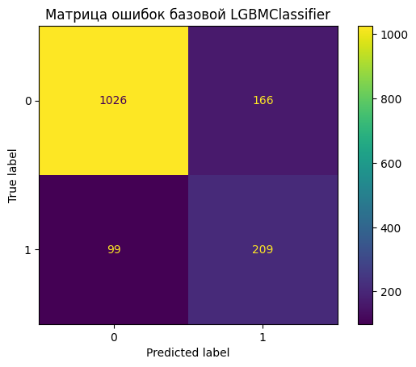

```python
conf_matrix = confusion_matrix(y_true=y_test, y_pred=lgbm_base.predict(X_test_fe_scale))
vis = ConfusionMatrixDisplay(confusion_matrix=conf_matrix, display_labels=lgbm_base.classes_)
vis.plot()
plt.title('Матрица ошибок базовой LGBMClassifier');
```

На втором графике с оптимизированной моделью посмотрим на `кол-во правильно предсказанных с таргем=1: их 219`.

**Интересная ситуация!** Эта модель по метрикам работает хуже, но оказывается `её ценность для нас больше, так как она побольше находит клиентов, собирающихся уйти из банка`. Таким образом мы смогли удержать дополнительно **10 клиентов** в нашем банке по сравнению с базовой моделью.

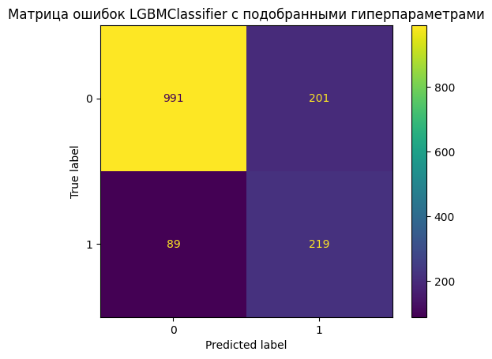

```python
conf_matrix = confusion_matrix(y_true=y_test, y_pred=lgbm_best.predict(X_test_fe_scale))
vis = ConfusionMatrixDisplay(confusion_matrix=conf_matrix, display_labels=lgbm_base.classes_)
vis.plot()
plt.title('Матрица ошибок LGBMClassifier с подобранными гиперпараметрами');
```

Посмотрим на **важность признаков оптимизированной модели**. Данный метод вычисляет важность объекта путем подсчета того, сколько раз признак использовался для разделения узлов по всем деревьям в модели.

**Мы видим**, что `оценочная зарплата`, `возраст`, `доля лежащей зарплаты на счету` и `баланс на счету` являются самыми частыми для предсказания модели: уйдёт ли клиент из банка или нет. Я думаю это объясняется тем, что если человек не пользуется услугами банка и не хранит деньги в нём, то данный банк ему незачем.

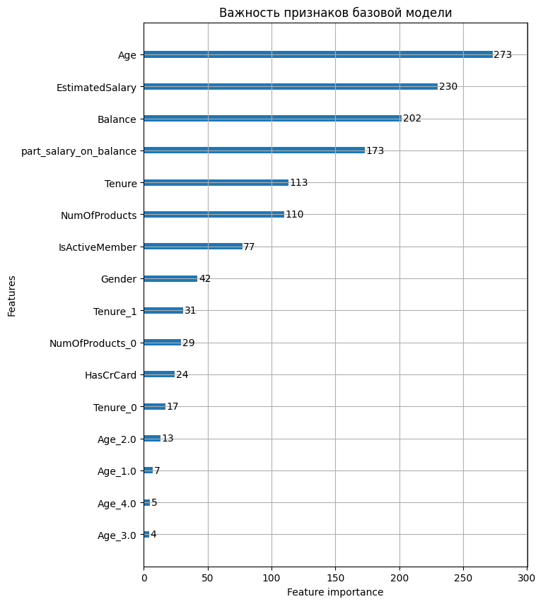

```python
lightgbm.plot_importance(lgbm_best, importance_type="split", figsize=(7,10), title="LightGBM Feature Importance (Split)")
plt.title('Важность признаков базовой модели')
plt.show()
```

Давайте попробуем объяснить почему `возраст` тоже важен. Посчитаем вероятность того, что клиенты старше 37 лет (медианный возраст в `train` выборке) покинут банк среди всех, кто покинул банк.

Мы видим, что **более старшие клиенты гораздо более склонны покинуть банк, чем клиенты до 37 лет**.

```python
df_tmp = X_train_fe_scale.copy()
df_tmp['Exited'] = y_train

prob = df_tmp[(df_tmp.Exited == 1) & (df_tmp.Age > df_tmp.Age.median())].shape[0] / df_tmp[(df_tmp.Exited == 1)].shape[0]
print(f'Вероятность того, что клиенты старше {int(df_tmp.Age.median())} лет (медианный возраст в `train` выборке)\n\
покинут банк среди всех, кто покинул банк равна = *{round(prob, 2)}*')
```

```
Вероятность того, что клиенты старше 37 лет (медианный возраст в `train` выборке)
покинут банк среди всех, кто покинул банк равна = *0.76*
```

**ROC-кривая** - данный график полезен для оценки производительности модели, особенно когда классы несбалансированы. Так как `ROC-AUC` ближе к единице, чем к 0.5, то можно сказать, что наша модель неплоха.

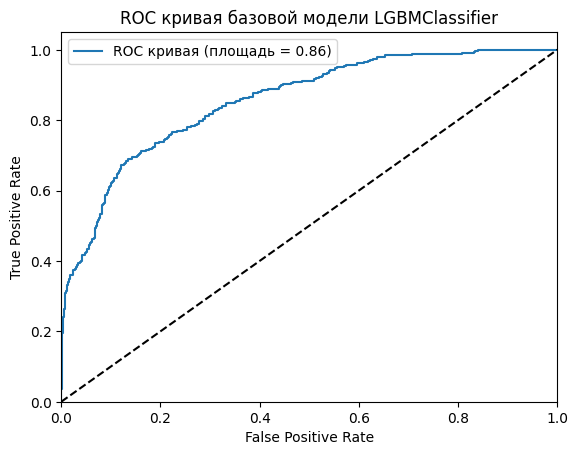

```python
fpr, tpr, thresholds = roc_curve(y_test, lgbm_best.predict_proba(X_test_fe_scale)[:, 1])
roc_auc = auc(fpr, tpr)
plt.figure()
plt.plot(fpr, tpr, label='ROC кривая (площадь = %0.2f)' % roc_auc)
plt.plot([0, 1], [0, 1], 'k--')
plt.xlim([0.0, 1.0])
plt.ylim([0.0, 1.05])
plt.xlabel('False Positive Rate')
plt.ylabel('True Positive Rate')
plt.title('ROC кривая базовой модели LGBMClassifier')
plt.legend()
plt.show()
```

# 5. Интеграция модели 🔥

**В данном разделе будут сделаны следующие пункты**:

- создадим небольшой класс, который будет содержать в себе модель и предобработку данных для новых клиентов
- добавим возможность схоранения модели в файл для повторного воспроизведения
- попробуем загрузить необработанный датасет и с помощью всего одной функции и получить результат

```python
import joblib
import pandas as pd
import numpy as np
from sklearn.preprocessing import KBinsDiscretizer
from lightgbm import LGBMClassifier
from category_encoders import OneHotEncoder


class Model:
    """Класс модели, в котором есть:
    1. предобработка данных
    2. предсказание модели
    3. сохранение модели для будущей загрузки

    С помощью данного класса модель можно, достаточно, легко
    интегрировать в какой-нибудь сервис.
    """

    def __init__(self, model=None):
        """model - любой объект модели, имеющий метод .predict(X: pd.DataFrame)"""
        self.model = model

    def save(self, filename: str) -> None:
        """Сохранение модели в файл.
        filename: str - путь/название файла, в который сохранить модель
        return: None"""
        joblib.dump(self, filename)
        print('Модель успешно сохранена.')

    def transform(self, X: pd.DataFrame) -> pd.DataFrame:
        """
        Предобработка данных.
        X: pd.DataFrame - датасет, который нужно предобработать для работы с моделью.
        return: pd.DataFrame - преобразованные данные."""
        X = X.copy()

        # Приводит датасет к нужному виду.
        X = X.drop(columns=['CustomerId'])
        X = X.astype({
            'HasCrCard': 'category',
            'IsActiveMember': 'category',
            'Gender': 'category',
            'NumOfProducts': 'category',
            'Tenure': 'category',
        })
        X.Gender = X.Gender.values.codes
        X.Gender = X.Gender.astype('category')

        # Создаём новый признак.
        X['part_salary_on_balance'] = X['Balance'] / X['EstimatedSalary']

        # Разбиение возраста на промежутки.
        bins = KBinsDiscretizer(n_bins=6)
        bins.fit(X[['Age']])
        tmp = bins.transform(X[['Age']]).toarray()
        X[bins.get_feature_names_out()] = tmp
        X = X.astype({name: 'int' for name in bins.get_feature_names_out()})

        # Кодирование категориальных признаков
        category_columns = ['Tenure', 'NumOfProducts']
        encoder = BaseNEncoder(
            cols=category_columns,
            drop_invariant=True,
            base=5,  # Основание кодирования
                     # Когда модель хорошо справляется с нелинейностями, стиот использовать более высокое значение.
        )
        encoder.fit(X)
        new_columns = encoder.get_feature_names_out()
        X[new_columns] = encoder.transform(X)

        # Масштабирование признаков
        num_columns = X.select_dtypes(include=['float64']).columns.tolist()
        scaler = MinMaxScaler()
        scaler.fit(X[num_columns])
        X[num_columns] = scaler.transform(X[num_columns])

        return X

    def predict(self, X: pd.DataFrame, preprocessing: bool=False) -> np.ndarray:
        """Предсказание моделью того, уйдёт ли клиент из банка или нет.
        X: pd.DataFrame - датасет, для которого делаем предсказание.
        preprocessing: Optional[bool] - нужно ли делать предобработку датасета для работы с моделью.
        return: np.ndarray - массив с метками предсказанного класса."""
        if preprocessing:
            X = self.transform(X)
        return self.model.predict(X)


def load(path: str) -> Model:
    """Загрузка модели из файла
    path: str - путь до файла модели.
    return: Model - объект модели."""
    return joblib.load(path)
```

**Сохраним модель:**

```python
model = Model(lgbm_best)
model.save('lgmb_classifier.pkl')
```

```
Модель успешно сохранена.
```

**Загрузим модель из файла:**

```python
model = load('lgmb_classifier.pkl')
```

**Считаем необработанный датасет:**

```python
df_example = pd.read_csv('data/dataset.csv').drop(columns=['Exited'])
df_example.head(2)
```

|  | CustomerId | Age | Gender | Tenure | Balance | NumOfProducts | HasCrCard | IsActiveMember | EstimatedSalary |
| --- | --- | --- | --- | --- | --- | --- | --- | --- | --- |
| 0 | 15634602 | 42 | Female | 2 | 0.00 | 1 | 1 | 1 | 101348.88 |
| 1 | 15647311 | 41 | Female | 1 | 83807.86 | 1 | 0 | 1 | 112542.58 |

**Сделаем предсказание на датасете с предвратительной обработкой данных:**

```python
model.predict(df_example, preprocessing=True)
```

```
array([1, 0, 1, ..., 0, 0, 1], dtype=int64)
```

**Сделаем предобработку данных отдельно и посмотрим на них:**

```python
df_example = model.transform(df_example)
df_example.head()
```

|  | Age | Gender | Tenure | Balance | NumOfProducts | HasCrCard | IsActiveMember | EstimatedSalary | part_salary_on_balance | Age_0.0 | Age_1.0 | Age_2.0 | Age_3.0 | Age_4.0 | Age_5.0 | Tenure_0 | Tenure_1 | NumOfProducts_0 |
| --- | --- | --- | --- | --- | --- | --- | --- | --- | --- | --- | --- | --- | --- | --- | --- | --- | --- | --- |
| 0 | 42 | 0 | 2 | 0.000000 | 1 | 1 | 1 | 0.506735 | 0.000000 | 0 | 0 | 0 | 0 | 1 | 0 | 0 | 1 | 1 |
| 1 | 41 | 0 | 1 | 0.334031 | 1 | 0 | 1 | 0.562709 | 0.000070 | 0 | 0 | 0 | 0 | 1 | 0 | 0 | 2 | 1 |
| 2 | 42 | 0 | 8 | 0.636357 | 3 | 1 | 0 | 0.569654 | 0.000132 | 0 | 0 | 0 | 0 | 1 | 0 | 0 | 3 | 2 |
| 3 | 39 | 0 | 1 | 0.000000 | 2 | 0 | 0 | 0.469120 | 0.000000 | 0 | 0 | 0 | 1 | 0 | 0 | 0 | 2 | 3 |
| 4 | 43 | 0 | 2 | 0.500246 | 1 | 1 | 1 | 0.395400 | 0.000150 | 0 | 0 | 0 | 0 | 1 | 0 | 0 | 1 | 1 |

**Сделаем прогноз на предобработанных данных:**

```python
model.predict(df_example)
```

```
array([1, 0, 1, ..., 0, 0, 1], dtype=int64)
```

## Спасибо большое за внимание!